# Effect for Those Who Have Not Received Vaccination Coupon in FY2019

Preview

Hiroki Kato

2022-03-12

## 2019年度ワクチンクーポン券送付対象外の男性に限定したナッジ・メッセージの効果

次に、2019年度には、クーポン券の送付対象ではないが、 オンデマンドでクーポン券を受け取れる人に限定して、 ナッジ・メッセージの効果を推定する。

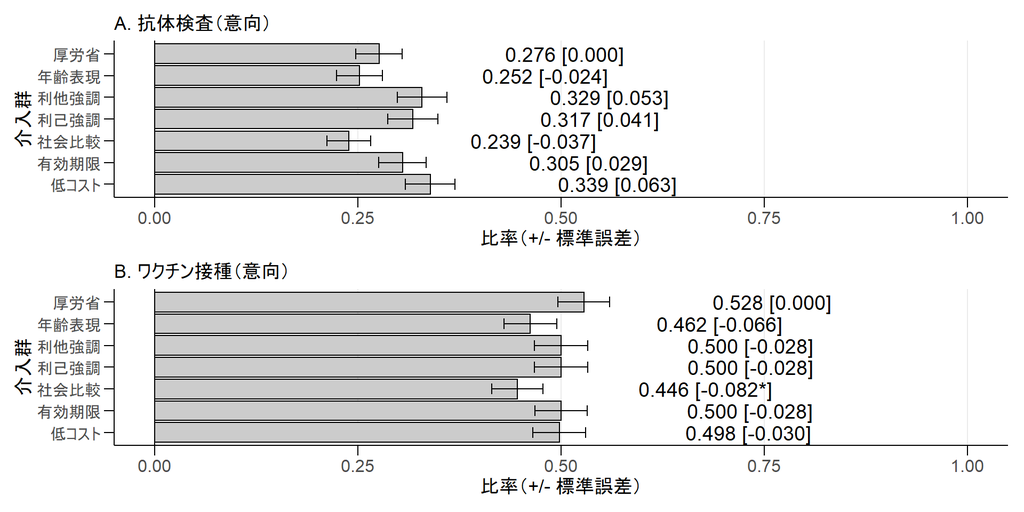

Figure 1: 2019年度クーポン券配布対象外の男性に限定した意向に対するナッジ・メッセージの効果。データソース：Wave 1セレクションデータ。注）図中の数値は各群の比率を示し、角括弧内の数値はナッジ・メッセージの効果の規模（厚労省メッセージ群との差）を示している。効果の統計的な有意性は次の規則に従う：* p < 0.1、** p < 0.05、*** p < 0.01。

また、社会比較メッセージは抗体検査受検の意向に対して統計的に有意な効果を持っていないが、 ワクチン接種の意向に対して負の効果を持っている。 厚労省メッセージを読んだ人の抗体検査受検とワクチン接種の意向の比率はそれぞれ約27.6%と約52.8%である。 それに対して、社会比較メッセージを読んだ人の抗体検査受検とワクチン接種の意向の比率はそれぞれ 約23.9%と約44.6%である。 したがって、社会比較メッセージの抗体検査受検の意向に対する効果は約-3.7%ポイントであり、 これは統計的に有意な効果ではない。 しかしながら、社会比較メッセージのワクチン接種の意向に対する効果は約-8.2%ポイントであり、 これは統計的に10%水準で有意である。

この負の効果の原因の一つとして、ワクチン接種のただ乗りが挙げられる。 社会比較メッセージは「5人に1人が抗体を持っていない」ことを強調している。 裏返せば、5人に4人が抗体を持っているということである。 このメッセージを読んだ人は、仮に風しんの抗体を保有していないとしても、 全体の80%が抗体を持っているので、自身が感染する機会は少ないと考えたのかもしれない。 クーポン券がない場合、 この信念がワクチンを接種することの価値を低め、ワクチン接種の意向の比率をコントロールよりも下げた可能性がある。

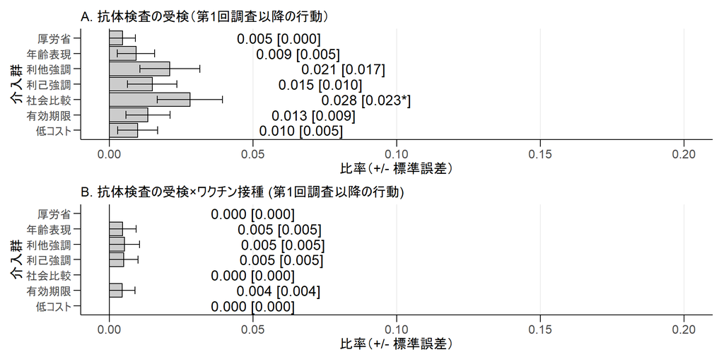

Figure 2: 2019年度クーポン券配布対象外の男性に限定した行動に対するナッジ・メッセージの効果。データソース：Wave 2セレクションデータ。注）図中の数値は各群の比率を示し、角括弧内の数値はナッジ・メッセージの効果の規模（厚労省メッセージ群との差）を示している。効果の統計的な有意性は次の規則に従う：* p < 0.1、** p < 0.05、*** p < 0.01。

図2は各介入群の第1回調査以降の抗体検査受検比率と 第1回調査以降のワクチン接種比率である。 社会比較メッセージが厚労省メッセージよりも第1回調査以降の抗体検査の受検を促進しているが、 抗体検査とワクチン接種の両方を促進していない。 厚労省メッセージを読んだ人の約0.5%が第1回調査以降に抗体検査を受検したが、 誰もワクチン接種をしていない。 また、社会比較メッセージを読んだ人の約2.8%が第1回調査以降に抗体検査を受検したが、 誰もワクチン接種をしていない。 よって、社会比較メッセージの抗体検査受検に対する効果は約2.3%ポイントであり、 これは統計的に10%水準で有意である。 しかしながら、抗体検査とワクチン接種の両方に対する効果はゼロである。

Table 1: 2019年度クーポン券配布対象外の男性に限定した 抗体検査とワクチン接種の線形確率モデルの推定結果

意向

第1回調査以降の行動

抗体検査

ワクチン接種

抗体検査

抗体検査×ワクチン接種

年齢表現

－0.024

－0.036

－0.066

－0.101**

0.005

0.004

0.005

0.005

(0.040)

(0.038)

(0.045)

(0.043)

(0.008)

(0.008)

(0.005)

(0.005)

利他強調

0.053

0.053

－0.028

－0.059

0.017

0.016

0.005

0.005

(0.042)

(0.042)

(0.045)

(0.045)

(0.011)

(0.011)

(0.005)

(0.005)

利己強調

0.041

0.026

－0.028

－0.053

0.010

0.009

0.005

0.005

(0.042)

(0.040)

(0.046)

(0.043)

(0.010)

(0.010)

(0.005)

(0.005)

社会比較

－0.037

－0.043

－0.082*

－0.098**

0.023*

0.022*

0.000

0.000

(0.039)

(0.038)

(0.045)

(0.042)

(0.012)

(0.012)

(0.001)

有効期限

0.029

0.029

－0.028

－0.043

0.009

0.009

0.004

0.005

(0.041)

(0.039)

(0.045)

(0.042)

(0.009)

(0.009)

(0.004)

(0.005)

低コスト

0.063

0.034

－0.030

－0.052

0.005

0.006

0.000

0.000

(0.042)

(0.040)

(0.045)

(0.043)

(0.008)

(0.008)

(0.001)

Num.Obs.

1688

1578

1688

1578

1467

1467

1467

1467

R2

0.006

0.107

0.003

0.125

0.004

0.019

0.002

0.013

R2 Adj.

0.003

0.095

－0.001

0.113

0.000

0.005

－0.002

－0.001

共変量

X

X

X

X

Table 2: 2019年度クーポン券配布対象外の抗体検査受検者の動き

| ナッジ・メッセージ | サンプルサイズ | 抗体検査の受検 人数 | 抗体検査の受検 二群比較のp値 | 抗体検査の結果が陰性 人数 | 抗体検査の結果が陰性 二群比較のp値 | 陰性かつワクチンを接種 人数 | 陰性かつワクチンを接種 二群比較のp値 |
| --- | --- | --- | --- | --- | --- | --- | --- |
| 厚労省 | 220 | 1 | － | 0 | － | 0 | － |
| 年齢表現 | 216 | 2 | 0.621 | 2 | 0.333 | 1 | － |
| 利他強調 | 190 | 4 | 0.187 | 1 | 1.000 | 1 | － |
| 利己強調 | 201 | 3 | 0.352 | 1 | 1.000 | 1 | － |
| 社会比較 | 214 | 6 | 0.065 | 1 | 1.000 | 0 | － |
| 有効期限 | 223 | 3 | 0.623 | 1 | 1.000 | 1 | － |
| 低コスト | 203 | 2 | 0.610 | 0 | 1.000 | 0 | － |

注）二群比較は、厚労省メッセージ群とあるナッジ・メッセージの二群をFisherの正確検定で分析している。抗体検査の受検をアウトカムとするとき、抗体検査の受検者数に群間で差がないという帰無仮説を検定している。抗体検査の陰性者をアウトカムとするとき、抗体検査の受検者の中で陰性者の比率に群間で差がないという帰無仮説を検定している。陰性者のワクチン接種をアウトカムとするとき、陰性者の中でワクチン接種の比率に群間で差がないという帰無仮説を検定している。